# Isomap

Tenenbaum, De Silva, & Langford. *A global geometric framework for nonlinear dimensionality reduction.* Science 290; 2000

Dimensionality reduction technique

- project data to lower dimension, preserving distances
  - Multidimensional Scaling "MDS" (1958)
- choose **geodesic distances**
  - Isomap (2000)

[figure not shown]

## Steps

1. Compute nearest neighborhood graph
   - $O[Dlog(k)Nlog(N)]$
2. Compute all shortest paths
   - $O[N^2 (k+log(N))]$
3. Partial eigenvalue decomposition for d-dimensional embedding
   - $O[dN^2]$
   - (MDS on graph/geodesic distances)

[scikit-learn](https://scikit-learn.org/stable/modules/manifold.html#isomap)

D = 4096

N = 698

[figure not shown]

## Examples

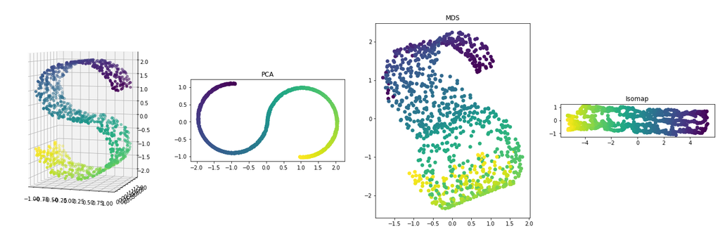

```python
compare_methods( X_s, color_s,
                [ PCA(n_components=2),
                MDS(2, max_iter=100, n_init=1),
                Isomap( n_components=2 ) ])
```

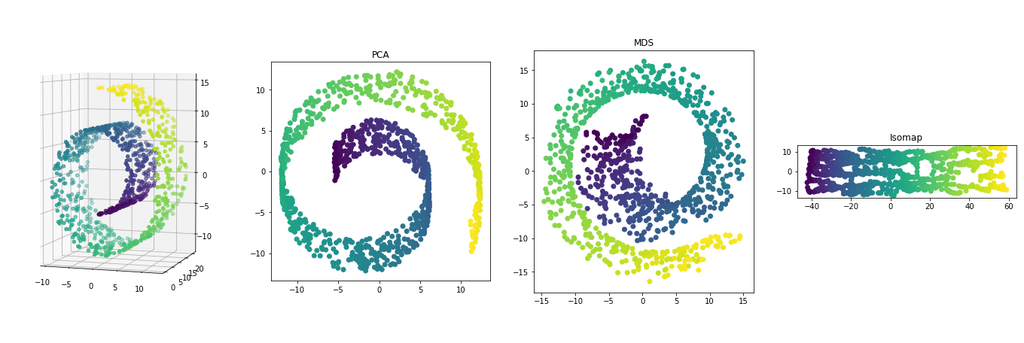

```python
compare_methods( X_swr, color_swr,
                [ PCA(n_components=2),
                MDS(2, max_iter=100, n_init=1),
                Isomap( n_components=2, n_neighbors=5 ) ])
```

## High dimensional data is ok

( if it's nice )

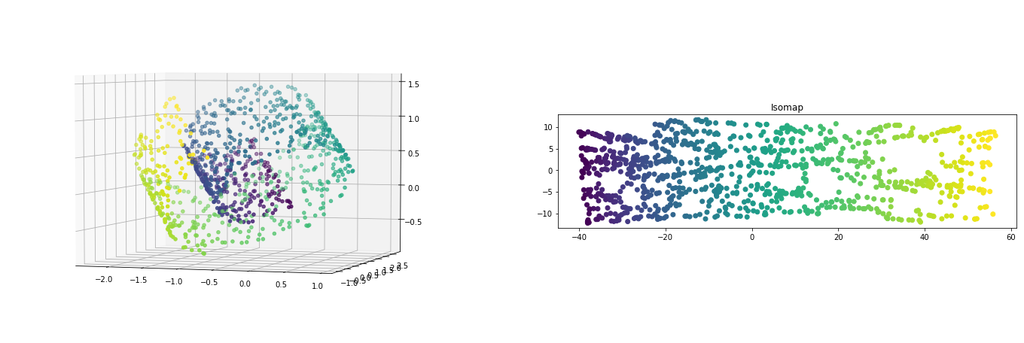

```python
# A random 500d orthonormal matrix
R = scipy.stats.ortho_group.rvs( 500 )
R3 = R[:,:3]

# nicely project our data up to 500d
X_swr_up = X_swr @ R3.T
X_swr_up.shape

compare_methods( X_swr_up, color_swr, [
    Isomap( n_components=2, n_neighbors=7 )
    ] )
```

# Multidimensional Scaling (MDS)

Potentially high-dim data ($\mathbf{y}_i$), but work directly on pairwise distances:

- $\mathbf{D} = [d_{ij}] $

Find low-dim data $\mathbf{x}_i$ that minimizes:

- $\Sigma_i \Sigma_{j \neq i} ( || \mathbf{x}_i -\mathbf{x}_j || - d_{ij})^2 $

## Method

1. "Double-center" distance matrix
   - B = $-\frac{1}{2}HD^2H$
1. Eigen-decompose $B$:
   - B = $U \Lambda U^T$
1. First $k$ eigenvectors yield low-dim space
   - $Y = U_k \Lambda_k^{\frac{1}{2}}$

### Why center distances?

Our original distance matrix is

$ D^2 = [d^2_{ij}] = (x_i - x_j)^T (x_i - x_j) $

Instead of working with $D^2$, we'll work with:

$B = -\frac{1}{2} H D^2 H $

$ B = (H X )^T ( H X ) = H X^T X H = \bar{X}^T \bar{X} $

$ b_{ij} = (x_i - \bar{x})^T (x_j - \bar{x})$

#### "The kernel trick for distances"

distances are invariant to fixed translations of all points. Expand out:

$ d_{ij} = [(x_i - \bar{x}) - (x_j - \bar{x}) ]^T [(x_i - \bar{x}) - (x_j - \bar{x}) ]$

The dot product is clearly not translation invariant:

$ x_i^T x_j \neq (x_i - \bar{x})^T (x_j - \bar{x})$

but mutiply out the translated version and collecting things together yields

$ \; = \frac{1}{2}( -|| x_i - x_j || + || x_i - \bar{x} || + || x_j - \bar{x} ||)$

Conclusion, for a fixed $\bar{x}$, we get a similarity measure $b_{ij}$ for every distance/dissimilarity || x_i - x_j ||

### Does this really work?

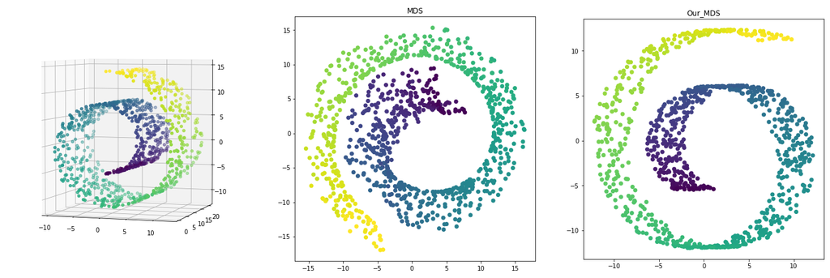

```python
def centering_mtx( N ):
    return np.identity(N) - np.ones(N) / N

class Our_MDS:
    n_dims =1
    def __init__(self, n_dims):
        self.n_dims = n_dims

    def fit_transform( self, X ):
        # Squared distances
        D = sklearn.metrics.pairwise.euclidean_distances( X, squared=True )
        H = centering_mtx( X.shape[0])
        B = -0.5 * H @ D @ H
        evals, eVecs = np.linalg.eigh( B )
        s = np.diagflat( np.sqrt( evals[-self.n_dims:] ) ) # Lambda^(1/2)
        v = eVecs[:, -self.n_dims:]
        return v @ s

compare_methods( X_swr, color_swr, [
    MDS( 2, max_iter=100, n_init=1),
    Our_MDS( 2 ) ] )
```

## References

Cox, T.F.; Cox, M.A.A. (2001). Multidimensional Scaling.

Kruskal, J. B., and Wish, M. (1978),

Williams "On a Connection between Kernel PCA and Metric Multidimensional Scaling"

[Kristin Branson's slides](https://cseweb.ucsd.edu/classes/fa02/cse252c/branson_isomap.pdf)

["The kernel trick for distances"](https://papers.nips.cc/paper/1862-the-kernel-trick-for-distances.pdf)

[Lecture notes on MDS and Isomap](http://www.math.uwaterloo.ca/~aghodsib/courses/f10stat946/notes/lec10-11.pdf)

[Relationship between Kernel PCA & MDS](https://papers.nips.cc/paper/1873-on-a-connection-between-kernel-pca-and-metric-multidimensional-scaling.pdf)

https://www.youtube.com/watch?v=RPjPLlGefzw

# Estimating geodesic distances

switch to [Kristin's slides](https://cseweb.ucsd.edu/classes/fa02/cse252c/branson_isomap.pdf)

# Finding shortest paths with Dijkstra's algorithm

(1956)

[figure not shown]

# Isomap failure modes

## Too few samples

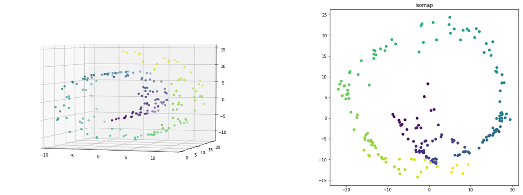

```python
X_loN, color_loN = sklearn.datasets.make_swiss_roll(n_samples=200, noise=0.01 )
compare_methods( X_loN, color_loN, [ Isomap( n_components=2, n_neighbors=5 ) ])
```

## High noise

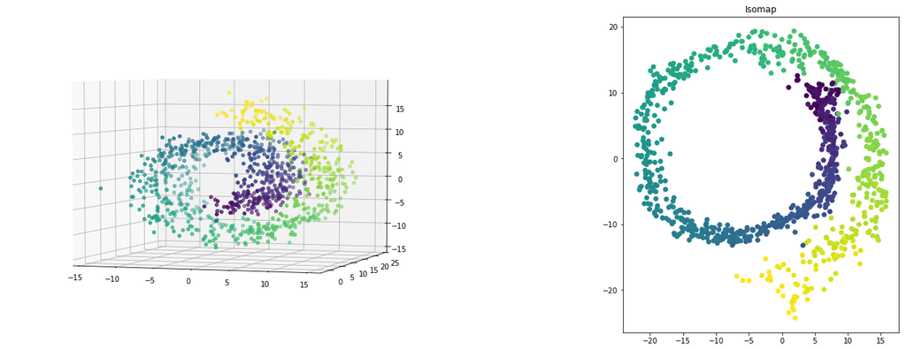

```python
X_loN, color_loN = sklearn.datasets.make_swiss_roll(n_samples=1000, noise=1.2 )
compare_methods( X_loN, color_loN, [ Isomap( n_components=2, n_neighbors=5 ) ])
```

# Non isotropic variable scaling

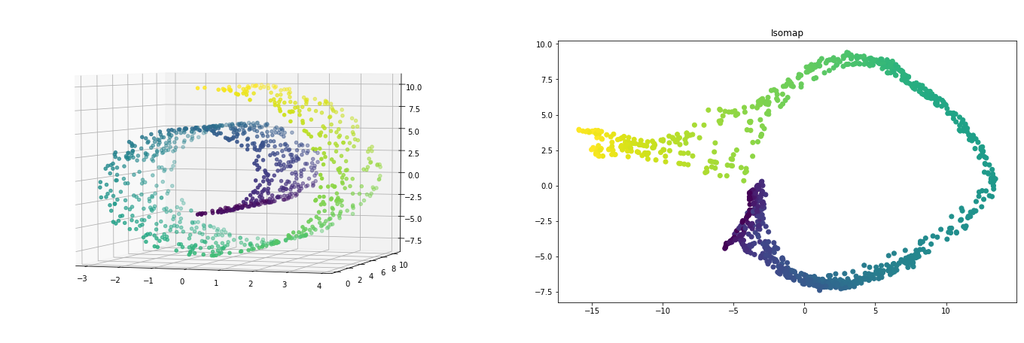

```python
scaling = np.diagflat(np.array([0.3,0.5,0.7]))
X_swr_scaled = X_swr @  scaling

compare_methods( X_swr_scaled, color_swr, [ Isomap( n_components=2, n_neighbors=7 ) ] )
```

## Poor parameter choice

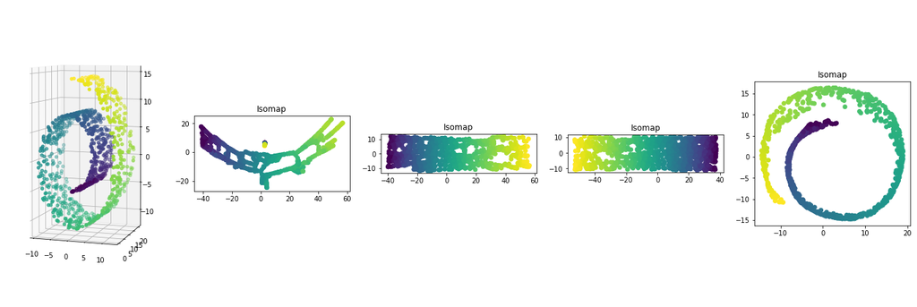

```python
compare_methods( X_swr, color_swr, [
    Isomap( n_components=2, n_neighbors=3 ),
    Isomap( n_components=2, n_neighbors=7 ),
    Isomap( n_components=2, n_neighbors=15 ),
    Isomap( n_components=2, n_neighbors=31 )] )
```

# An application

Chaudhuri et al. ["The intrinsic attractor manifold and population dynamics of a canonical cognitive circuit across waking and sleep"](https://www.nature.com/articles/s41593-019-0460-x) Nature neuroscience 2019

*If a circuit represents a low-dimensional variable of given dimension and topology, the high-dimensional states of the circuit will be localized to a low-dimensional subspace or manifold of matching dimension and topology.*

- Look for 1d ring manifold for head direction representation in mouse
- Persistent homology (topological data analysis) to find likely topology/dimension of subspace
- **Isomap for dimensionality reduction and visualization**
- Fit low-d spline to the manifod: the "latent variable"

### Isomap preprocessing

Neuronal state-space is very high-dimensional. Reduce dimensionality for practical reasons (e.g. so spline fitting is faster).

[figure not shown]

- "This visualization provides a compelling mammalian parallel to the beautiful recent results on a topographically ordered HD ring in the invertebrate nervous system"
- "A manifold approach reveals the full N-point correlations of the circuit, directly uncovering a structure that cannot easily be obtained from individual neural responses and pairwise correlations, including that there is little structure beyond a single 1D ring ..."
- "Manifold characterization with topological data analysis followed by parameterization in local coordinates as done here rather than by global low-dimensional embedding (as done by, for example, PCA and Isomap) will be important for unsupervised decoding of higher-dimensional manifolds that are topologically nontrivial, for example, toroidal structures produced by simulated grid cells"

a) isomap

b) VAE

c) outlier removal

d) no outlier removal

[figure not shown]